# Risk Factor Analysis

## Outcome Variable

**Outcome Variable:** haz

## Predictor Variables

**Intervention Variable:** impsan

**Adjustment Set:**

unadjusted

## Stratifying Variables

The analysis was stratified on these variable(s):

- agecat
- studyid
- country

## Data Summary

| agecat | studyid | country | impsan | n_cell | n |
| --- | --- | --- | --- | --- | --- |
| Birth | COHORTS | GUATEMALA | 1 | 45 | 491 |
| Birth | COHORTS | GUATEMALA | 0 | 446 | 491 |
| Birth | COHORTS | INDIA | 1 | 1767 | 4776 |
| Birth | COHORTS | INDIA | 0 | 3009 | 4776 |
| Birth | COHORTS | PHILIPPINES | 1 | 178 | 1191 |
| Birth | COHORTS | PHILIPPINES | 0 | 1013 | 1191 |
| Birth | CONTENT | PERU | 1 | 1 | 2 |
| Birth | CONTENT | PERU | 0 | 1 | 2 |
| Birth | JiVitA-3 | BANGLADESH | 1 | 15220 | 22431 |
| Birth | JiVitA-3 | BANGLADESH | 0 | 7211 | 22431 |
| Birth | JiVitA-4 | BANGLADESH | 1 | 2181 | 2820 |
| Birth | JiVitA-4 | BANGLADESH | 0 | 639 | 2820 |
| Birth | MAL-ED | BANGLADESH | 1 | 179 | 213 |
| Birth | MAL-ED | BANGLADESH | 0 | 34 | 213 |
| Birth | MAL-ED | BRAZIL | 1 | 59 | 60 |
| Birth | MAL-ED | BRAZIL | 0 | 1 | 60 |
| Birth | MAL-ED | INDIA | 1 | 15 | 40 |
| Birth | MAL-ED | INDIA | 0 | 25 | 40 |
| Birth | MAL-ED | NEPAL | 1 | 25 | 26 |
| Birth | MAL-ED | NEPAL | 0 | 1 | 26 |
| Birth | MAL-ED | PERU | 1 | 52 | 208 |
| Birth | MAL-ED | PERU | 0 | 156 | 208 |
| Birth | MAL-ED | SOUTH AFRICA | 1 | 0 | 95 |
| Birth | MAL-ED | SOUTH AFRICA | 0 | 95 | 95 |
| Birth | MAL-ED | TANZANIA, UNITED REPUBLIC OF | 1 | 0 | 118 |
| Birth | MAL-ED | TANZANIA, UNITED REPUBLIC OF | 0 | 118 | 118 |
| Birth | NIH-Birth | BANGLADESH | 1 | 231 | 608 |
| Birth | NIH-Birth | BANGLADESH | 0 | 377 | 608 |
| Birth | NIH-Crypto | BANGLADESH | 1 | 632 | 721 |
| Birth | NIH-Crypto | BANGLADESH | 0 | 89 | 721 |

[output cut: 70 more lines]

The following strata were considered:

- agecat: 24 months, studyid: COHORTS, country: GUATEMALA
- agecat: 24 months, studyid: COHORTS, country: INDIA
- agecat: 24 months, studyid: COHORTS, country: PHILIPPINES
- agecat: 24 months, studyid: CONTENT, country: PERU
- agecat: 24 months, studyid: JiVitA-3, country: BANGLADESH
- agecat: 24 months, studyid: JiVitA-4, country: BANGLADESH
- agecat: 24 months, studyid: LCNI-5, country: MALAWI
- agecat: 24 months, studyid: MAL-ED, country: BANGLADESH
- agecat: 24 months, studyid: MAL-ED, country: BRAZIL
- agecat: 24 months, studyid: MAL-ED, country: INDIA
- agecat: 24 months, studyid: MAL-ED, country: NEPAL
- agecat: 24 months, studyid: MAL-ED, country: PERU
- agecat: 24 months, studyid: MAL-ED, country: SOUTH AFRICA
- agecat: 24 months, studyid: MAL-ED, country: TANZANIA, UNITED REPUBLIC OF
- agecat: 24 months, studyid: NIH-Birth, country: BANGLADESH
- agecat: 24 months, studyid: NIH-Crypto, country: BANGLADESH
- agecat: 24 months, studyid: PROVIDE, country: BANGLADESH
- agecat: 6 months, studyid: COHORTS, country: GUATEMALA
- agecat: 6 months, studyid: COHORTS, country: INDIA
- agecat: 6 months, studyid: COHORTS, country: PHILIPPINES
- agecat: 6 months, studyid: CONTENT, country: PERU
- agecat: 6 months, studyid: JiVitA-3, country: BANGLADESH
- agecat: 6 months, studyid: JiVitA-4, country: BANGLADESH
- agecat: 6 months, studyid: LCNI-5, country: MALAWI
- agecat: 6 months, studyid: MAL-ED, country: BANGLADESH
- agecat: 6 months, studyid: MAL-ED, country: BRAZIL
- agecat: 6 months, studyid: MAL-ED, country: INDIA
- agecat: 6 months, studyid: MAL-ED, country: NEPAL
- agecat: 6 months, studyid: MAL-ED, country: PERU
- agecat: 6 months, studyid: MAL-ED, country: SOUTH AFRICA
- agecat: 6 months, studyid: MAL-ED, country: TANZANIA, UNITED REPUBLIC OF
- agecat: 6 months, studyid: NIH-Birth, country: BANGLADESH
- agecat: 6 months, studyid: NIH-Crypto, country: BANGLADESH
- agecat: 6 months, studyid: PROVIDE, country: BANGLADESH
- agecat: Birth, studyid: COHORTS, country: GUATEMALA
- agecat: Birth, studyid: COHORTS, country: INDIA
- agecat: Birth, studyid: COHORTS, country: PHILIPPINES
- agecat: Birth, studyid: CONTENT, country: PERU
- agecat: Birth, studyid: JiVitA-3, country: BANGLADESH
- agecat: Birth, studyid: JiVitA-4, country: BANGLADESH
- agecat: Birth, studyid: MAL-ED, country: BANGLADESH
- agecat: Birth, studyid: MAL-ED, country: BRAZIL
- agecat: Birth, studyid: MAL-ED, country: INDIA
- agecat: Birth, studyid: MAL-ED, country: NEPAL
- agecat: Birth, studyid: MAL-ED, country: PERU
- agecat: Birth, studyid: MAL-ED, country: SOUTH AFRICA
- agecat: Birth, studyid: MAL-ED, country: TANZANIA, UNITED REPUBLIC OF
- agecat: Birth, studyid: NIH-Birth, country: BANGLADESH
- agecat: Birth, studyid: NIH-Crypto, country: BANGLADESH
- agecat: Birth, studyid: PROVIDE, country: BANGLADESH

### Dropped Strata

Some strata were dropped due to rare outcomes:

- agecat: Birth, studyid: CONTENT, country: PERU
- agecat: Birth, studyid: MAL-ED, country: BRAZIL
- agecat: Birth, studyid: MAL-ED, country: NEPAL
- agecat: Birth, studyid: MAL-ED, country: SOUTH AFRICA
- agecat: Birth, studyid: MAL-ED, country: TANZANIA, UNITED REPUBLIC OF
- agecat: Birth, studyid: PROVIDE, country: BANGLADESH
- agecat: 6 months, studyid: LCNI-5, country: MALAWI
- agecat: 6 months, studyid: MAL-ED, country: BRAZIL
- agecat: 6 months, studyid: MAL-ED, country: NEPAL
- agecat: 6 months, studyid: MAL-ED, country: SOUTH AFRICA
- agecat: 6 months, studyid: MAL-ED, country: TANZANIA, UNITED REPUBLIC OF
- agecat: 6 months, studyid: PROVIDE, country: BANGLADESH
- agecat: 24 months, studyid: LCNI-5, country: MALAWI
- agecat: 24 months, studyid: MAL-ED, country: BRAZIL
- agecat: 24 months, studyid: MAL-ED, country: NEPAL
- agecat: 24 months, studyid: MAL-ED, country: SOUTH AFRICA
- agecat: 24 months, studyid: MAL-ED, country: TANZANIA, UNITED REPUBLIC OF
- agecat: 24 months, studyid: PROVIDE, country: BANGLADESH

## Methods Detail

We’re interested in the causal parameters $E[Y_a]$ for all values of $a \in \mathcal{A}$. These parameters represent the mean outcome if, possibly contrary to fact, we intervened to set all units to have $A=a$. Under the randomization and positivity assumptions, these are identified by the statistical parameters $\psi_a=E_W[E_{Y|A,W}(Y|A=a,W)]$. In addition, we’re interested in the mean of $Y$, $E[Y]$ under no intervention (the observed mean). We will estimate these parameters by using SuperLearner to fit the relevant likelihood factors – $E_{Y|A,W}(Y|A=a,W)$ and $p(A=a|W)$, and then updating our likelihood fit using a joint TMLE.

For unadjusted analyses ($W=\{\}$), initial likelihoods were estimated using Lrnr_glm to estimate the simple $E(Y|A)$ and Lrnr_mean to estimate $p(A)$. For adjusted analyses, a small library containing Lrnr_glmnet, Lrnr_xgboost, and Lrnr_mean was used.

# Results Detail

## Results Plots

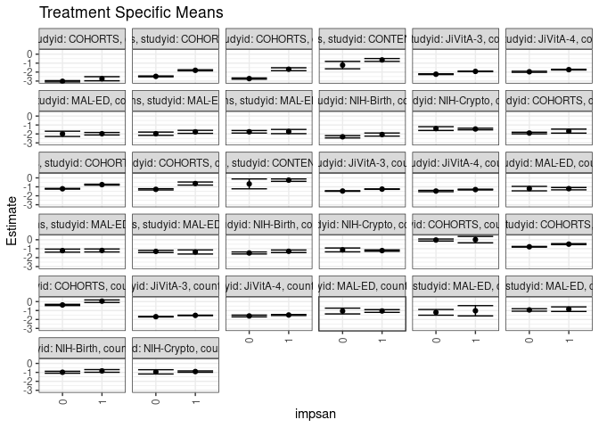

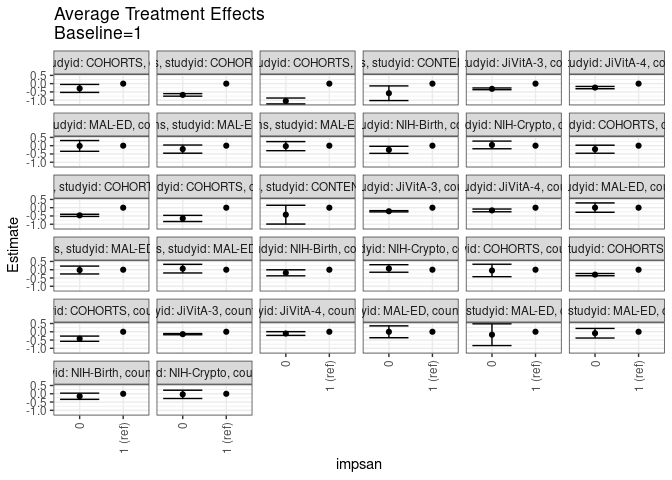

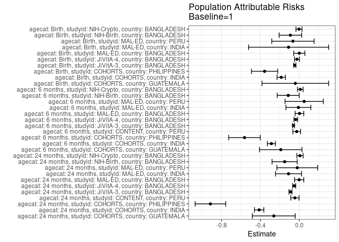

## Results Table

### Parameter: TSM

| agecat | studyid | country | intervention_level | baseline_level | estimate | ci_lower | ci_upper |
| --- | --- | --- | --- | --- | --- | --- | --- |
| Birth | COHORTS | GUATEMALA | 1 | NA | 0.0140000 | -0.3450346 | 0.3730346 |
| Birth | COHORTS | GUATEMALA | 0 | NA | -0.0317265 | -0.1454192 | 0.0819663 |
| Birth | COHORTS | INDIA | 1 | NA | -0.4914658 | -0.5448741 | -0.4380574 |
| Birth | COHORTS | INDIA | 0 | NA | -0.7870821 | -0.8283252 | -0.7458390 |
| Birth | COHORTS | PHILIPPINES | 1 | NA | 0.0435393 | -0.0987359 | 0.1858146 |
| Birth | COHORTS | PHILIPPINES | 0 | NA | -0.3765153 | -0.4451537 | -0.3078769 |
| Birth | JiVitA-3 | BANGLADESH | 1 | NA | -1.5426991 | -1.5652562 | -1.5201420 |
| Birth | JiVitA-3 | BANGLADESH | 0 | NA | -1.6893038 | -1.7198174 | -1.6587903 |
| Birth | JiVitA-4 | BANGLADESH | 1 | NA | -1.4992114 | -1.5552778 | -1.4431450 |
| Birth | JiVitA-4 | BANGLADESH | 0 | NA | -1.6069014 | -1.7058922 | -1.5079106 |
| Birth | MAL-ED | BANGLADESH | 1 | NA | -1.0526257 | -1.2029283 | -0.9023231 |
| Birth | MAL-ED | BANGLADESH | 0 | NA | -1.0552941 | -1.3803733 | -0.7302149 |
| Birth | MAL-ED | INDIA | 1 | NA | -1.0266667 | -1.5999108 | -0.4534225 |
| Birth | MAL-ED | INDIA | 0 | NA | -1.2040000 | -1.5243954 | -0.8836046 |
| Birth | MAL-ED | PERU | 1 | NA | -0.8467308 | -1.1029994 | -0.5904622 |
| Birth | MAL-ED | PERU | 0 | NA | -0.9353205 | -1.0703392 | -0.8003018 |
| Birth | NIH-Birth | BANGLADESH | 1 | NA | -0.8387662 | -0.9904115 | -0.6871209 |
| Birth | NIH-Birth | BANGLADESH | 0 | NA | -0.9875464 | -1.0959553 | -0.8791375 |
| Birth | NIH-Crypto | BANGLADESH | 1 | NA | -0.9088608 | -0.9838653 | -0.8338562 |
| Birth | NIH-Crypto | BANGLADESH | 0 | NA | -0.9432584 | -1.1826640 | -0.7038529 |
| 6 months | COHORTS | GUATEMALA | 1 | NA | -1.6874627 | -1.9137285 | -1.4611969 |
| 6 months | COHORTS | GUATEMALA | 0 | NA | -1.9006261 | -1.9881552 | -1.8130969 |
| 6 months | COHORTS | INDIA | 1 | NA | -0.7542743 | -0.8056832 | -0.7028654 |
| 6 months | COHORTS | INDIA | 0 | NA | -1.2162524 | -1.2572688 | -1.1752361 |
| 6 months | COHORTS | PHILIPPINES | 1 | NA | -0.6306993 | -0.8028673 | -0.4585313 |
| 6 months | COHORTS | PHILIPPINES | 0 | NA | -1.2800319 | -1.3505196 | -1.2095442 |
| 6 months | CONTENT | PERU | 1 | NA | -0.2511642 | -0.3854795 | -0.1168488 |
| 6 months | CONTENT | PERU | 0 | NA | -0.6713571 | -1.2232977 | -0.1194166 |
| 6 months | JiVitA-3 | BANGLADESH | 1 | NA | -1.2526857 | -1.2783672 | -1.2270041 |
| 6 months | JiVitA-3 | BANGLADESH | 0 | NA | -1.4671651 | -1.5012388 | -1.4330913 |
| 6 months | JiVitA-4 | BANGLADESH | 1 | NA | -1.3073889 | -1.3492812 | -1.2654965 |
| 6 months | JiVitA-4 | BANGLADESH | 0 | NA | -1.4695142 | -1.5422678 | -1.3967606 |
| 6 months | MAL-ED | BANGLADESH | 1 | NA | -1.2035726 | -1.3352035 | -1.0719417 |
| 6 months | MAL-ED | BANGLADESH | 0 | NA | -1.1979386 | -1.4474372 | -0.9484400 |
| 6 months | MAL-ED | INDIA | 1 | NA | -1.1986574 | -1.3652549 | -1.0320599 |
| 6 months | MAL-ED | INDIA | 0 | NA | -1.2174267 | -1.3874425 | -1.0474108 |
| 6 months | MAL-ED | PERU | 1 | NA | -1.3688205 | -1.5979310 | -1.1397100 |
| 6 months | MAL-ED | PERU | 0 | NA | -1.3034722 | -1.4282605 | -1.1786840 |
| 6 months | NIH-Birth | BANGLADESH | 1 | NA | -1.2924553 | -1.4351827 | -1.1497279 |
| 6 months | NIH-Birth | BANGLADESH | 0 | NA | -1.4783459 | -1.5908332 | -1.3658586 |
| 6 months | NIH-Crypto | BANGLADESH | 1 | NA | -1.2126829 | -1.2888615 | -1.1365043 |
| 6 months | NIH-Crypto | BANGLADESH | 0 | NA | -1.1369101 | -1.3508747 | -0.9229455 |
| 24 months | COHORTS | GUATEMALA | 1 | NA | -2.7423377 | -2.9712843 | -2.5133910 |
| 24 months | COHORTS | GUATEMALA | 0 | NA | -3.0298775 | -3.1040020 | -2.9557529 |
| 24 months | COHORTS | INDIA | 1 | NA | -1.7996329 | -1.8596850 | -1.7395808 |
| 24 months | COHORTS | INDIA | 0 | NA | -2.4791404 | -2.5275812 | -2.4306995 |
| 24 months | COHORTS | PHILIPPINES | 1 | NA | -1.6802381 | -1.8437996 | -1.5166765 |
| 24 months | COHORTS | PHILIPPINES | 0 | NA | -2.7269792 | -2.7984300 | -2.6555284 |
| 24 months | CONTENT | PERU | 1 | NA | -0.6409603 | -0.8000011 | -0.4819194 |
| 24 months | CONTENT | PERU | 0 | NA | -1.2200000 | -1.6347170 | -0.8052830 |
| 24 months | JiVitA-3 | BANGLADESH | 1 | NA | -1.9223859 | -1.9541454 | -1.8906263 |
| 24 months | JiVitA-3 | BANGLADESH | 0 | NA | -2.2359219 | -2.2794938 | -2.1923501 |
| 24 months | JiVitA-4 | BANGLADESH | 1 | NA | -1.7272332 | -1.7678952 | -1.6865713 |
| 24 months | JiVitA-4 | BANGLADESH | 0 | NA | -1.9643045 | -2.0242380 | -1.9043710 |
| 24 months | MAL-ED | BANGLADESH | 1 | NA | -1.9763812 | -2.1159002 | -1.8368622 |
| 24 months | MAL-ED | BANGLADESH | 0 | NA | -1.9901613 | -2.2838591 | -1.6964635 |
| 24 months | MAL-ED | INDIA | 1 | NA | -1.7666346 | -1.9354118 | -1.5978575 |
| 24 months | MAL-ED | INDIA | 0 | NA | -1.9736364 | -2.1543797 | -1.7928930 |
| 24 months | MAL-ED | PERU | 1 | NA | -1.7320213 | -1.9673298 | -1.4967127 |
| 24 months | MAL-ED | PERU | 0 | NA | -1.7603020 | -1.9034269 | -1.6171771 |
| 24 months | NIH-Birth | BANGLADESH | 1 | NA | -2.0677843 | -2.2398347 | -1.8957339 |
| 24 months | NIH-Birth | BANGLADESH | 0 | NA | -2.3183494 | -2.4440778 | -2.1926210 |
| 24 months | NIH-Crypto | BANGLADESH | 1 | NA | -1.4479908 | -1.5402265 | -1.3557550 |
| 24 months | NIH-Crypto | BANGLADESH | 0 | NA | -1.4028571 | -1.6140474 | -1.1916669 |

### Parameter: E(Y)

| agecat | studyid | country | intervention_level | baseline_level | estimate | ci_lower | ci_upper |
| --- | --- | --- | --- | --- | --- | --- | --- |
| Birth | COHORTS | GUATEMALA | NA | NA | -0.0275356 | -0.1359303 | 0.0808590 |
| Birth | COHORTS | INDIA | NA | NA | -0.6777115 | -0.7106054 | -0.6448175 |
| Birth | COHORTS | PHILIPPINES | NA | NA | -0.3137364 | -0.3764483 | -0.2510244 |
| Birth | JiVitA-3 | BANGLADESH | NA | NA | -1.5898288 | -1.6090823 | -1.5705753 |
| Birth | JiVitA-4 | BANGLADESH | NA | NA | -1.5236135 | -1.5727559 | -1.4744711 |
| Birth | MAL-ED | BANGLADESH | NA | NA | -1.0530516 | -1.1896058 | -0.9164975 |
| Birth | MAL-ED | INDIA | NA | NA | -1.1375000 | -1.4325178 | -0.8424822 |
| Birth | MAL-ED | PERU | NA | NA | -0.9131731 | -1.0331160 | -0.7932301 |
| Birth | NIH-Birth | BANGLADESH | NA | NA | -0.9310197 | -1.0197391 | -0.8423003 |
| Birth | NIH-Crypto | BANGLADESH | NA | NA | -0.9131068 | -0.9851939 | -0.8410197 |
| 6 months | COHORTS | GUATEMALA | NA | NA | -1.8789210 | -1.9609921 | -1.7968498 |
| 6 months | COHORTS | INDIA | NA | NA | -1.0414424 | -1.0741113 | -1.0087734 |
| 6 months | COHORTS | PHILIPPINES | NA | NA | -1.1942936 | -1.2608624 | -1.1277248 |
| 6 months | CONTENT | PERU | NA | NA | -0.2785256 | -0.4098735 | -0.1471776 |
| 6 months | JiVitA-3 | BANGLADESH | NA | NA | -1.3134804 | -1.3366079 | -1.2903528 |
| 6 months | JiVitA-4 | BANGLADESH | NA | NA | -1.3440477 | -1.3813060 | -1.3067894 |
| 6 months | MAL-ED | BANGLADESH | NA | NA | -1.2026806 | -1.3203025 | -1.0850586 |
| 6 months | MAL-ED | INDIA | NA | NA | -1.2087268 | -1.3282418 | -1.0892117 |
| 6 months | MAL-ED | PERU | NA | NA | -1.3196229 | -1.4293681 | -1.2098778 |
| 6 months | NIH-Birth | BANGLADESH | NA | NA | -1.4073821 | -1.4960598 | -1.3187043 |
| 6 months | NIH-Crypto | BANGLADESH | NA | NA | -1.2031037 | -1.2749632 | -1.1312442 |
| 24 months | COHORTS | GUATEMALA | NA | NA | -3.0050840 | -3.0758338 | -2.9343342 |
| 24 months | COHORTS | INDIA | NA | NA | -2.2126633 | -2.2518337 | -2.1734929 |
| 24 months | COHORTS | PHILIPPINES | NA | NA | -2.5937576 | -2.6629996 | -2.5245156 |
| 24 months | CONTENT | PERU | NA | NA | -0.6868598 | -0.8388476 | -0.5348719 |
| 24 months | JiVitA-3 | BANGLADESH | NA | NA | -2.0136975 | -2.0413718 | -1.9860232 |
| 24 months | JiVitA-4 | BANGLADESH | NA | NA | -1.7803708 | -1.8158650 | -1.7448765 |
| 24 months | MAL-ED | BANGLADESH | NA | NA | -1.9783962 | -2.1050210 | -1.8517715 |
| 24 months | MAL-ED | INDIA | NA | NA | -1.8779556 | -2.0033207 | -1.7525904 |
| 24 months | MAL-ED | PERU | NA | NA | -1.7535204 | -1.8760973 | -1.6309435 |
| 24 months | NIH-Birth | BANGLADESH | NA | NA | -2.2190579 | -2.3217459 | -2.1163699 |
| 24 months | NIH-Crypto | BANGLADESH | NA | NA | -1.4417097 | -1.5263855 | -1.3570340 |

### Parameter: ATE

| agecat | studyid | country | intervention_level | baseline_level | estimate | ci_lower | ci_upper |
| --- | --- | --- | --- | --- | --- | --- | --- |
| Birth | COHORTS | GUATEMALA | 1 | 1 | 0.0000000 | 0.0000000 | 0.0000000 |
| Birth | COHORTS | GUATEMALA | 0 | 1 | -0.0457265 | -0.4223322 | 0.3308793 |
| Birth | COHORTS | INDIA | 1 | 1 | 0.0000000 | 0.0000000 | 0.0000000 |
| Birth | COHORTS | INDIA | 0 | 1 | -0.2956163 | -0.3630956 | -0.2281371 |
| Birth | COHORTS | PHILIPPINES | 1 | 1 | 0.0000000 | 0.0000000 | 0.0000000 |
| Birth | COHORTS | PHILIPPINES | 0 | 1 | -0.4200546 | -0.5780214 | -0.2620879 |
| Birth | JiVitA-3 | BANGLADESH | 1 | 1 | 0.0000000 | 0.0000000 | 0.0000000 |
| Birth | JiVitA-3 | BANGLADESH | 0 | 1 | -0.1466048 | -0.1822674 | -0.1109421 |
| Birth | JiVitA-4 | BANGLADESH | 1 | 1 | 0.0000000 | 0.0000000 | 0.0000000 |
| Birth | JiVitA-4 | BANGLADESH | 0 | 1 | -0.1076900 | -0.2206428 | 0.0052627 |
| Birth | MAL-ED | BANGLADESH | 1 | 1 | 0.0000000 | 0.0000000 | 0.0000000 |
| Birth | MAL-ED | BANGLADESH | 0 | 1 | -0.0026684 | -0.3608128 | 0.3554759 |
| Birth | MAL-ED | INDIA | 1 | 1 | 0.0000000 | 0.0000000 | 0.0000000 |
| Birth | MAL-ED | INDIA | 0 | 1 | -0.1773333 | -0.8340388 | 0.4793721 |
| Birth | MAL-ED | PERU | 1 | 1 | 0.0000000 | 0.0000000 | 0.0000000 |
| Birth | MAL-ED | PERU | 0 | 1 | -0.0885897 | -0.3782510 | 0.2010715 |
| Birth | NIH-Birth | BANGLADESH | 1 | 1 | 0.0000000 | 0.0000000 | 0.0000000 |
| Birth | NIH-Birth | BANGLADESH | 0 | 1 | -0.1487802 | -0.3351904 | 0.0376301 |
| Birth | NIH-Crypto | BANGLADESH | 1 | 1 | 0.0000000 | 0.0000000 | 0.0000000 |
| Birth | NIH-Crypto | BANGLADESH | 0 | 1 | -0.0343977 | -0.2852775 | 0.2164822 |
| 6 months | COHORTS | GUATEMALA | 1 | 1 | 0.0000000 | 0.0000000 | 0.0000000 |
| 6 months | COHORTS | GUATEMALA | 0 | 1 | -0.2131634 | -0.4557692 | 0.0294424 |
| 6 months | COHORTS | INDIA | 1 | 1 | 0.0000000 | 0.0000000 | 0.0000000 |
| 6 months | COHORTS | INDIA | 0 | 1 | -0.4619781 | -0.5277445 | -0.3962117 |
| 6 months | COHORTS | PHILIPPINES | 1 | 1 | 0.0000000 | 0.0000000 | 0.0000000 |
| 6 months | COHORTS | PHILIPPINES | 0 | 1 | -0.6493326 | -0.8353711 | -0.4632941 |
| 6 months | CONTENT | PERU | 1 | 1 | 0.0000000 | 0.0000000 | 0.0000000 |
| 6 months | CONTENT | PERU | 0 | 1 | -0.4201930 | -0.9882414 | 0.1478554 |
| 6 months | JiVitA-3 | BANGLADESH | 1 | 1 | 0.0000000 | 0.0000000 | 0.0000000 |
| 6 months | JiVitA-3 | BANGLADESH | 0 | 1 | -0.2144794 | -0.2520130 | -0.1769458 |
| 6 months | JiVitA-4 | BANGLADESH | 1 | 1 | 0.0000000 | 0.0000000 | 0.0000000 |
| 6 months | JiVitA-4 | BANGLADESH | 0 | 1 | -0.1621253 | -0.2443124 | -0.0799383 |
| 6 months | MAL-ED | BANGLADESH | 1 | 1 | 0.0000000 | 0.0000000 | 0.0000000 |
| 6 months | MAL-ED | BANGLADESH | 0 | 1 | 0.0056340 | -0.2764586 | 0.2877266 |
| 6 months | MAL-ED | INDIA | 1 | 1 | 0.0000000 | 0.0000000 | 0.0000000 |
| 6 months | MAL-ED | INDIA | 0 | 1 | -0.0187693 | -0.2568031 | 0.2192646 |
| 6 months | MAL-ED | PERU | 1 | 1 | 0.0000000 | 0.0000000 | 0.0000000 |
| 6 months | MAL-ED | PERU | 0 | 1 | 0.0653483 | -0.1955420 | 0.3262386 |
| 6 months | NIH-Birth | BANGLADESH | 1 | 1 | 0.0000000 | 0.0000000 | 0.0000000 |
| 6 months | NIH-Birth | BANGLADESH | 0 | 1 | -0.1858906 | -0.3676170 | -0.0041642 |
| 6 months | NIH-Crypto | BANGLADESH | 1 | 1 | 0.0000000 | 0.0000000 | 0.0000000 |
| 6 months | NIH-Crypto | BANGLADESH | 0 | 1 | 0.0757728 | -0.1513484 | 0.3028940 |
| 24 months | COHORTS | GUATEMALA | 1 | 1 | 0.0000000 | 0.0000000 | 0.0000000 |
| 24 months | COHORTS | GUATEMALA | 0 | 1 | -0.2875398 | -0.5281868 | -0.0468927 |
| 24 months | COHORTS | INDIA | 1 | 1 | 0.0000000 | 0.0000000 | 0.0000000 |
| 24 months | COHORTS | INDIA | 0 | 1 | -0.6795074 | -0.7566617 | -0.6023532 |
| 24 months | COHORTS | PHILIPPINES | 1 | 1 | 0.0000000 | 0.0000000 | 0.0000000 |
| 24 months | COHORTS | PHILIPPINES | 0 | 1 | -1.0467411 | -1.2252280 | -0.8682541 |
| 24 months | CONTENT | PERU | 1 | 1 | 0.0000000 | 0.0000000 | 0.0000000 |
| 24 months | CONTENT | PERU | 0 | 1 | -0.5790397 | -1.0232066 | -0.1348729 |
| 24 months | JiVitA-3 | BANGLADESH | 1 | 1 | 0.0000000 | 0.0000000 | 0.0000000 |
| 24 months | JiVitA-3 | BANGLADESH | 0 | 1 | -0.3135361 | -0.3652510 | -0.2618211 |
| 24 months | JiVitA-4 | BANGLADESH | 1 | 1 | 0.0000000 | 0.0000000 | 0.0000000 |
| 24 months | JiVitA-4 | BANGLADESH | 0 | 1 | -0.2370713 | -0.3073578 | -0.1667847 |
| 24 months | MAL-ED | BANGLADESH | 1 | 1 | 0.0000000 | 0.0000000 | 0.0000000 |
| 24 months | MAL-ED | BANGLADESH | 0 | 1 | -0.0137801 | -0.3389322 | 0.3113721 |
| 24 months | MAL-ED | INDIA | 1 | 1 | 0.0000000 | 0.0000000 | 0.0000000 |
| 24 months | MAL-ED | INDIA | 0 | 1 | -0.2070017 | -0.4542948 | 0.0402914 |
| 24 months | MAL-ED | PERU | 1 | 1 | 0.0000000 | 0.0000000 | 0.0000000 |
| 24 months | MAL-ED | PERU | 0 | 1 | -0.0282807 | -0.3036983 | 0.2471368 |
| 24 months | NIH-Birth | BANGLADESH | 1 | 1 | 0.0000000 | 0.0000000 | 0.0000000 |
| 24 months | NIH-Birth | BANGLADESH | 0 | 1 | -0.2505651 | -0.4636589 | -0.0374713 |
| 24 months | NIH-Crypto | BANGLADESH | 1 | 1 | 0.0000000 | 0.0000000 | 0.0000000 |
| 24 months | NIH-Crypto | BANGLADESH | 0 | 1 | 0.0451336 | -0.1853197 | 0.2755870 |

### Parameter: PAR

| agecat | studyid | country | intervention_level | baseline_level | estimate | ci_lower | ci_upper |
| --- | --- | --- | --- | --- | --- | --- | --- |
| Birth | COHORTS | GUATEMALA | 1 | NA | -0.0415356 | -0.3836276 | 0.3005563 |
| Birth | COHORTS | INDIA | 1 | NA | -0.1862457 | -0.2289516 | -0.1435398 |
| Birth | COHORTS | PHILIPPINES | 1 | NA | -0.3572757 | -0.4919028 | -0.2226486 |
| Birth | JiVitA-3 | BANGLADESH | 1 | NA | -0.0471297 | -0.0586875 | -0.0355720 |
| Birth | JiVitA-4 | BANGLADESH | 1 | NA | -0.0244021 | -0.0498385 | 0.0010342 |
| Birth | MAL-ED | BANGLADESH | 1 | NA | -0.0004259 | -0.0575947 | 0.0567428 |
| Birth | MAL-ED | INDIA | 1 | NA | -0.1108333 | -0.5221577 | 0.3004910 |
| Birth | MAL-ED | PERU | 1 | NA | -0.0664423 | -0.2837511 | 0.1508665 |
| Birth | NIH-Birth | BANGLADESH | 1 | NA | -0.0922535 | -0.2079828 | 0.0234758 |
| Birth | NIH-Crypto | BANGLADESH | 1 | NA | -0.0042460 | -0.0352256 | 0.0267335 |
| 6 months | COHORTS | GUATEMALA | 1 | NA | -0.1914583 | -0.4094168 | 0.0265002 |
| 6 months | COHORTS | INDIA | 1 | NA | -0.2871680 | -0.3285206 | -0.2458155 |
| 6 months | COHORTS | PHILIPPINES | 1 | NA | -0.5635943 | -0.7255986 | -0.4015901 |
| 6 months | CONTENT | PERU | 1 | NA | -0.0273614 | -0.0668727 | 0.0121499 |
| 6 months | JiVitA-3 | BANGLADESH | 1 | NA | -0.0607947 | -0.0716799 | -0.0499095 |
| 6 months | JiVitA-4 | BANGLADESH | 1 | NA | -0.0366588 | -0.0552731 | -0.0180445 |
| 6 months | MAL-ED | BANGLADESH | 1 | NA | 0.0008921 | -0.0437734 | 0.0455575 |
| 6 months | MAL-ED | INDIA | 1 | NA | -0.0100693 | -0.1377756 | 0.1176369 |
| 6 months | MAL-ED | PERU | 1 | NA | 0.0491976 | -0.1472438 | 0.2456389 |
| 6 months | NIH-Birth | BANGLADESH | 1 | NA | -0.1149268 | -0.2275389 | -0.0023147 |
| 6 months | NIH-Crypto | BANGLADESH | 1 | NA | 0.0095792 | -0.0191938 | 0.0383523 |
| 24 months | COHORTS | GUATEMALA | 1 | NA | -0.2627463 | -0.4827071 | -0.0427856 |
| 24 months | COHORTS | INDIA | 1 | NA | -0.4130304 | -0.4611147 | -0.3649461 |
| 24 months | COHORTS | PHILIPPINES | 1 | NA | -0.9135195 | -1.0707999 | -0.7562390 |
| 24 months | CONTENT | PERU | 1 | NA | -0.0458995 | -0.0885180 | -0.0032810 |
| 24 months | JiVitA-3 | BANGLADESH | 1 | NA | -0.0913117 | -0.1069348 | -0.0756885 |
| 24 months | JiVitA-4 | BANGLADESH | 1 | NA | -0.0531375 | -0.0689860 | -0.0372891 |
| 24 months | MAL-ED | BANGLADESH | 1 | NA | -0.0020150 | -0.0495654 | 0.0455354 |
| 24 months | MAL-ED | INDIA | 1 | NA | -0.1113209 | -0.2449947 | 0.0223528 |
| 24 months | MAL-ED | PERU | 1 | NA | -0.0214991 | -0.2308796 | 0.1878813 |
| 24 months | NIH-Birth | BANGLADESH | 1 | NA | -0.1512736 | -0.2804475 | -0.0220996 |
| 24 months | NIH-Crypto | BANGLADESH | 1 | NA | 0.0062810 | -0.0258191 | 0.0383812 |